# Resale Flat Price

7 November 2019

### Summary

- Data sourced from: [Resale Flat Price](https://data.gov.sg/dataset/resale-flat-prices)
- Unsurpisingly, resale flats which fetch a higher price are ones that are bigger and higher.
- Houses nearest to the MRT also fetch a higher price, but only within a distance of 1 km.

### 1. Set Up

```r
library(dplyr)
library(lubridate)
library(ggplot2)
library(forcats)
library(geosphere)

RFP <- readr::read_csv("data/resale-flat-prices-based-on-registration-date-from-jan-2017-onwards.csv")
```

```r
RFP = RFP %>%
  mutate(month = parse_date_time(month, "Ym"),
         town = as.factor(town),
         flat_type = as.factor(flat_type),
         address = paste("Block", block, street_name),
         storey_range = as.factor(storey_range),
         flat_model = as.factor(flat_model),
         months_left = year(period(remaining_lease)) * 12 + month(period(remaining_lease)),
         resale_price = resale_price / 1000
  )
options(scipen = 999)
```

### 2. Variable Relationship with Resale Prices

#### a. Towns

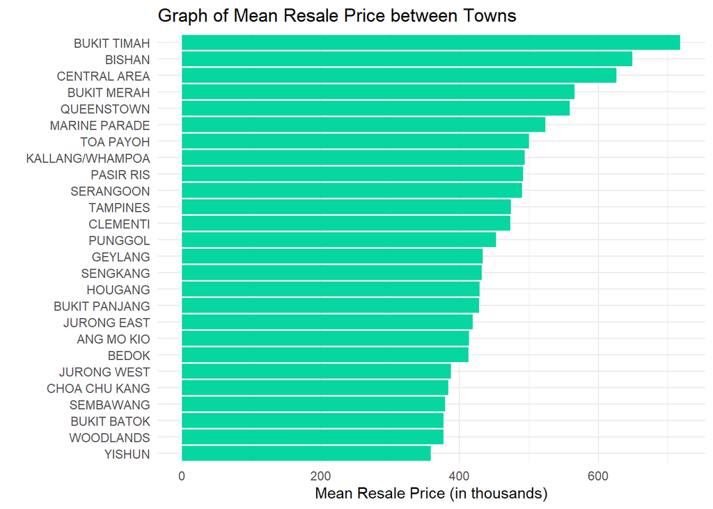

```r
RFP %>%

  group_by(town) %>%
  summarise(mean.resale_price = mean(resale_price)) %>%

  ggplot(aes(y = mean.resale_price, x = fct_reorder(town, mean.resale_price))) +
  geom_col(fill = "#06d6a0") +

  labs(title = "Graph of Mean Resale Price between Towns",
       y = "Mean Resale Price (in thousands)",
       x = "") +
  theme_minimal() +
  coord_flip()
```

#### b. Flat Type

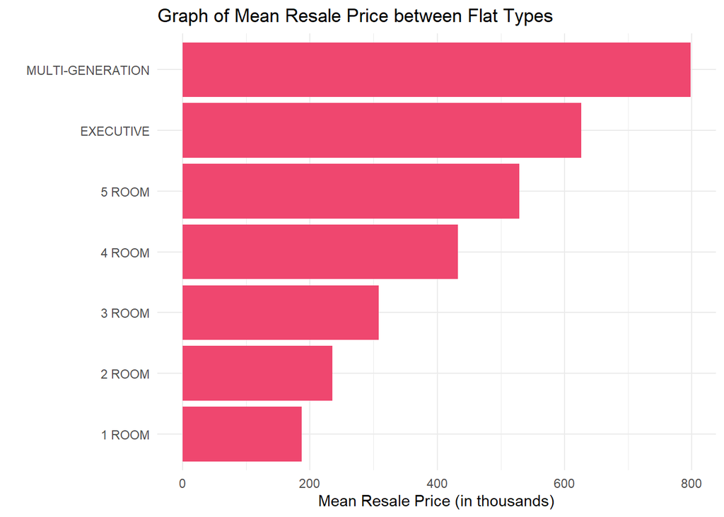

```r
RFP %>%

  group_by(flat_type) %>%
  summarise(mean.resale_price = mean(resale_price)) %>%

  ggplot(aes(y = mean.resale_price, x = fct_reorder(flat_type, mean.resale_price))) +
  geom_col(fill = "#ef476f") +

  labs(title = "Graph of Mean Resale Price between Flat Types",
       y = "Mean Resale Price (in thousands)",
       x = "") +
  theme_minimal() +
  coord_flip()
```

#### c. Storey Range

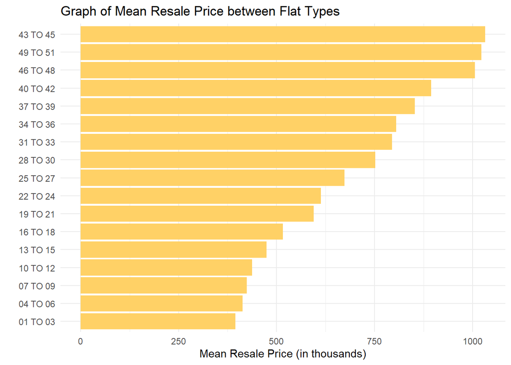

```r
RFP %>%

  group_by(storey_range) %>%
  summarise(mean.resale_price = mean(resale_price)) %>%

  ggplot(aes(y = mean.resale_price, x = fct_reorder(storey_range, mean.resale_price))) +
  geom_col(fill = "#ffd166") +

  labs(title = "Graph of Mean Resale Price between Flat Types",
       y = "Mean Resale Price (in thousands)",
       x = "") +
  theme_minimal() +
  coord_flip()
```

- Also unsurprisingly, the higher the flat, the higher the resale price.
- Change in price appears to be lower at the lowest and highest storey ranges.

#### d. Floor Area

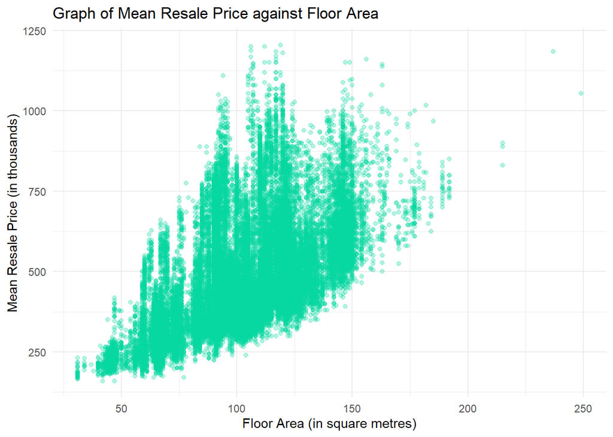

```r
RFP %>%

  ggplot(aes(y = resale_price, x = floor_area_sqm)) +
  geom_point(col = "#06d6a0", alpha = 0.3) +

  labs(title = "Graph of Mean Resale Price against Floor Area",
       y = "Mean Resale Price (in thousands)",
       x = "Floor Area (in square metres)") +
  theme_minimal()
```

- The graph shows an interesting relationship between the two variables, where there appears to be a exponential relationship between the two variables; but at the same time a huge variance in the prices for each floor area.

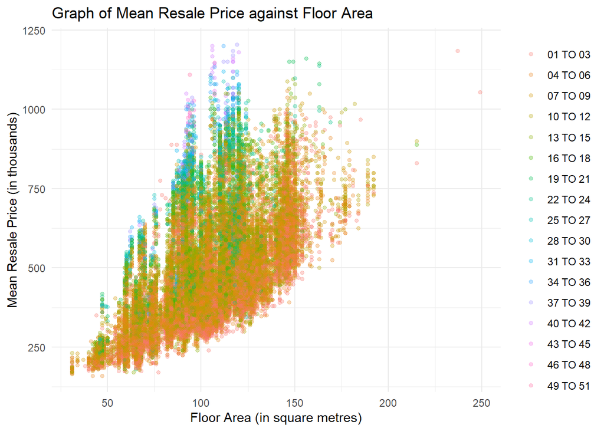

```r
RFP %>%

  ggplot(aes(y = resale_price, x = floor_area_sqm, col = storey_range)) +
  geom_point(alpha = 0.3, size = 1.2) +

  labs(title = "Graph of Mean Resale Price against Floor Area",
       y = "Mean Resale Price (in thousands)",
       x = "Floor Area (in square metres)",
       col = "") +
  theme_minimal()
```

#### e. Flat Model

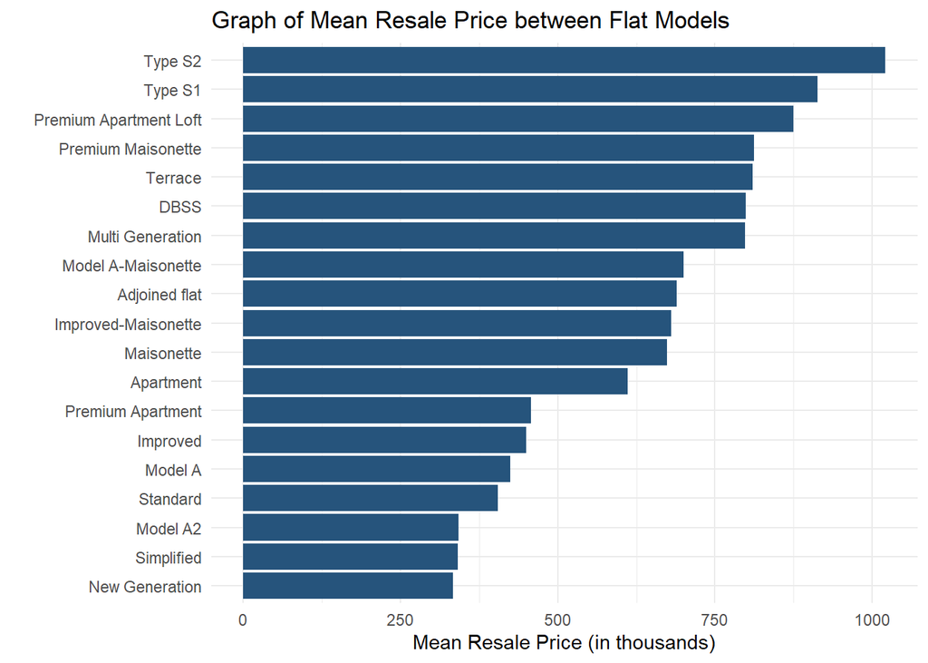

```r
RFP %>%

  group_by(flat_model) %>%
  summarise(mean.resale_price = mean(resale_price)) %>%

  ggplot(aes(y = mean.resale_price, x = fct_reorder(flat_model, mean.resale_price))) +
  geom_col(fill = "#26547c") +

  labs(title = "Graph of Mean Resale Price between Flat Models",
       y = "Mean Resale Price (in thousands)",
       x = "") +
  theme_minimal() +
  coord_flip()
```

- As expected, flat models such as DBSS and Terraces fetch a higher resale price than normal HDBs.

#### f. Months Left

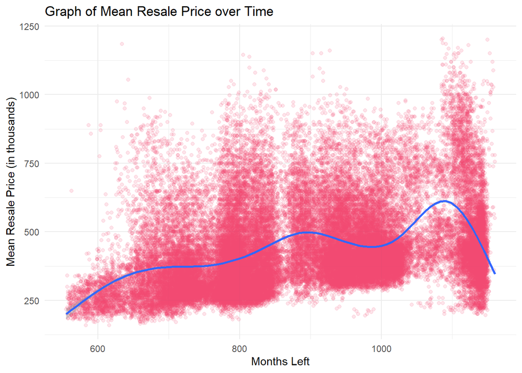

```r
RFP %>%

  ggplot(aes(y = resale_price, x = months_left)) +
  geom_point(col = "#ef476f", alpha = 0.15) +
  geom_smooth() +

  labs(title = "Graph of Mean Resale Price over Time",
       y = "Mean Resale Price (in thousands)",
       x = "Months Left") +
  theme_minimal()
```

- Prices of HDB fluctuate over time, but the trend is that prices decrease over time.
- Variace for each given month left is likely due other variables such as floor area, town and flat type.

### 3. Location to MRT

#### Geocoding each address

```
unique_addr <- unique(RFP$address)
register_google(key = api)
addr_geocode <- geocode(unique_addr)

addr_df = cbind(unique_addr, addr_geocode)
addr_df_complete = addr_df[ , c(2, 4, 5)]
colnames(addr_df_complete) = c("address", "long", "lat")
```

- Addresses were geocoded using the google maps api, and the mrt locations were geocoded and saved.
- Unique addresses were geocoded as it reduced the number of geocodes from 56 to 8 thousand.
- Also, geocoding uses credits.

```r
addr_df_complete = read.csv("data/addr_df_complete.csv", stringsAsFactors = FALSE)
mrt_locations = read.csv("data/MRT_locations.csv", stringsAsFactors = FALSE)

for (i in 1:NROW(addr_df_complete)) {

  addr_df_complete$nearestMRTdist[i] =
    distHaversine(p1 = addr_df_complete[i, c("long", "lat")],
                  p2 = mrt_locations[ , c("long", "lat")]) %>%
    min()
}
```

- `distHaversine` function was used to calculate the distance between each address to all mrt locations, based on their `long` and `lat` values.

```r
RFP = left_join(RFP, addr_df_complete, by = "address")
```

#### b. Relationship between Distance to Nearest MRT and Resale Price

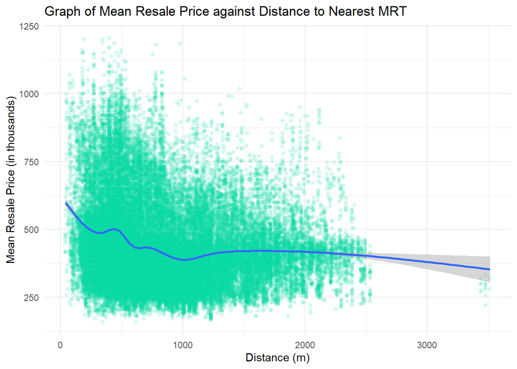

```r
RFP %>%

  ggplot(aes(y = resale_price, x = nearestMRTdist)) +
  geom_point(col = "#06d6a0", alpha = 0.15) +
  geom_smooth() +

  labs(title = "Graph of Mean Resale Price against Distance to Nearest MRT",
       y = "Mean Resale Price (in thousands)",
       x = "Distance (m)") +
  theme_minimal()
```

- Graph is a little confusing

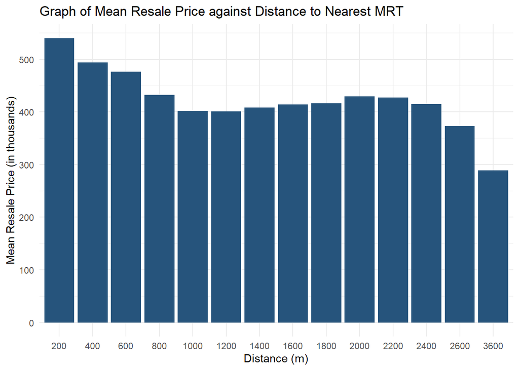

```r
RFP %>%
  mutate(group = cut(nearestMRTdist,
                     breaks = seq(0, 4000, by = 200),
                     labels = seq(200, 4000, by = 200))) %>%
  group_by(group) %>%
  summarise(mean.resale_price = mean(resale_price)) %>%

  ggplot(aes(y = mean.resale_price, x = group)) +
  geom_col(fill = "#26547c") +

  labs(title = "Graph of Mean Resale Price against Distance to Nearest MRT",
       x = "Distance (m)",
       y = "Mean Resale Price (in thousands)") +
  scale_y_continuous(breaks=seq(0, 500, 100)) +
  theme_minimal()
```

- Flats nearer to the MRT fetch a higher price, but the effect tapers out at about 1 km away from the MRT. Following which there is a slight incline.